# Stein’s Paradox, Decision and Pooling

Author

Michael Issa

Published

August 2024

Stein’s paradox is a striking result in statistical decision theory published by [Charles Stein](https://en.wikipedia.org/wiki/Charles_M._Stein) in 1955. As a mathematical result, it is exquisite. The underlying sensitivity to the dimensionality of a problem (as with many other results) is surprising at first but subsides as you learn to write the proof down for yourself. What you end up with is a theorem telling you that given a decision rule, a loss function, and a function of those two (the risk function), you can prove that an estimator is better in some non-trivial way. Now, it doesn’t tell you that it’s the best or that it’s better than most. It only tells you that compared to this other estimator, it’s better. You might feel dejected after hearing this. Fear not! I think this result points to some very deep connections in the foundations of statistics: the purported distinction between inference and decision, how we think of our underlying data-generating process, and it also segues quite nicely into more useful techniques in contemporary statistical practice, like multilevel models.

# 1 Computational Environment Setup

```python
import arviz as az
import matplotlib.pyplot as plt
import numpy as np
import seaborn as sns
import warnings
import os
warnings.filterwarnings("ignore")

# Graphic configuration
c_light = "#DCBCBC"
c_light_highlight = "#C79999"
c_mid = "#B97C7C"
c_mid_highlight = "#A25050"
c_dark = "#8F2727"
c_dark_highlight = "#7C0000"

c_light_teal = "#6B8E8E"
c_mid_teal = "#487575"
c_dark_teal = "#1D4F4F"

RANDOM_SEED = 58583389
np.random.seed(RANDOM_SEED)
az.style.use("arviz-darkgrid")

plt.rcParams['font.family'] = 'serif'

plt.rcParams['xtick.labelsize'] = 12
plt.rcParams['ytick.labelsize'] = 12
plt.rcParams['axes.labelsize'] = 12
plt.rcParams['axes.titlesize'] = 12

plt.rcParams['axes.spines.top'] = False
plt.rcParams['axes.spines.right'] = False
plt.rcParams['axes.spines.left'] = True
plt.rcParams['axes.spines.bottom'] = True

plt.rcParams['axes.xmargin'] = 0
plt.rcParams['axes.ymargin'] = 0

plt.subplots_adjust(left=0.15, bottom=0.15, right=0.9, top=0.85)

current_working_directory = os.getcwd()
```

# 2 Stein’s Paradox

## 2.1 Maximum Likelihood and the James-Stein Estimator

To report a point estimate for a parameter of interest $\theta$, you usually use maximum likelihood estimation, which chooses the estimate $\hat{\theta}$ that maximizes the likelihood function,

$$\hat{\theta}_{\text{MLE}} = \underset{\theta}{\operatorname{arg\,max}} \, \mathcal{L}(\theta \mid x).$$

This provides a very natural interpretation of $\hat{\theta}$ as the ‘most likely’ value. For example, if we sample the test scores of a school and find the average of our sample is 75%, anyone would assume that it’s most likely the population average is also 75%. What justifies this? Well, MLE justifies this. There is a mountain of results about how MLE has all these desirable properties, but we’re interested in its decision-theoretic justification.

Given a loss function that measures the inaccuracy of an estimator based on the squared difference or error:

$$L(\hat{\theta}, \theta) = (\hat{\theta} - \theta)^2 \\$$

the risk of the estimator, which is the expected value of this loss function, is:

$$R(\hat{\theta}, \theta) = \mathbb{E}[(\hat{\theta} - \theta)^2] \\$$

The estimator is considered better if it has a lower risk. For the sample mean $\bar{X}$ and the median, the risk of the sample mean is always less than or equal to the risk of the median for all possible values of $\theta$:

$$R(\bar{X}, \theta) \leq R(\text{median}, \theta), \quad \forall \theta \in \Theta$$

The mean [dominates](https://en.wikipedia.org/wiki/Dominating_decision_rule) the median in this case, and the median is ruled inadmissible. You can find a proof of this result on [Wikipedia](https://en.wikipedia.org/wiki/Stein%27s_example#Sketched_proof)

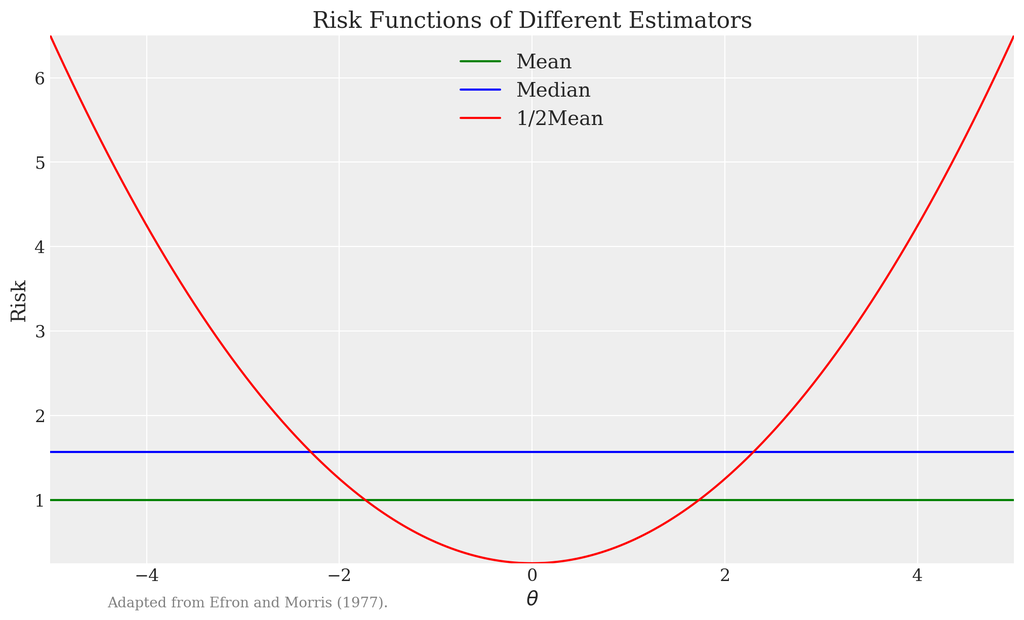

```python
theta = np.linspace(-5, 5, 400)

risk_mean = np.ones_like(theta)
risk_median = 1.57 * risk_mean
risk_half_mean = (theta**2 + 1) / 4

plt.figure(figsize=(10, 6))
plt.plot(theta, risk_mean, label='Mean', color='green')
plt.plot(theta, risk_median, label='Median', color='blue')
plt.plot(theta, risk_half_mean, label='1/2Mean', color='red')

plt.xlabel(r'$\theta$', fontsize=14)
plt.ylabel('Risk', fontsize=14)
plt.title('Risk Functions of Different Estimators', fontsize=16)
plt.legend()
plt.grid(True)

plt.figtext(0.1, 0.01, 'Adapted from Efron and Morris (1977).',
            ha='left', fontsize=10, color='gray')

plt.show()
```

We see that as long as you’re estimating one or two variables, the mean is admissible. But what Stein showed is that if you want to estimate three or more variables together, then the mean is inadmissible. He provided one such estimator that performs better than MLE because it “shrinks” the MLE towards 0. This coefficient of shrinkage is:

$$c = 1 - \frac{\sigma^2}{\sum_{i=1}^{3} X_i}$$

where the $X_i$ are the ith MLE estimate of our sample. In the case of population heights, this is the sample mean. Multiplying the sample mean by this coefficient of shrinkage results in a better estimate because it minimizes the expected error.

## 2.2 An aside on the coefficient of 1.57 in the median risk

This section may be skipped. I couldn’t find a sufficient derivation of this from a quick Google search, so I went through the work of deriving it.

Let’s derive the formula for the density of the sample median at the population median, denoted by $f(\mu)$.

For a sample of $n$ independent and identically distributed (i.i.d.) random variables $X_1, X_2, \ldots, X_n$ from a continuous distribution with cumulative distribution function $F(x)$ and probability density function $f(x)$, the order statistics are the sorted values $X_{(1)} \leq X_{(2)} \leq \dots \leq X_{(n)}$.

The median $M$ of the sample is the $\left(\frac{n+1}{2}\right)$th order statistic when $n$ is odd, or the average of the two middle order statistics when $n$ is even. The distribution of the median, $M$, can be approximated using the concept of order statistics. We focus on the density at the population median $\mu$.

The probability that the sample median $M$ is less than or equal to a value $x$ is given by:

$$P(M \leq x) = P\left(X_{\left(\frac{n+1}{2}\right)} \leq x\right)$$

The median is the order statistic around which half of the sample lies below and half above. The distribution of the order statistic is given by:

$$P(M \leq x) = \sum_{k=\left\lceil \frac{n+1}{2} \right\rceil}^{n} \binom{n}{k} [F(x)]^k [1 - F(x)]^{n-k}$$

However, we are interested in the density function $f_M(x)$ at $x = \mu$, the population median. The density of the median $M$ at $x = \mu$ can be approximated for large $n$ as:

$$f_M(x) \approx \frac{n!}{\left(\frac{n}{2}!\right)^2} [F(x)]^{n/2} [1 - F(x)]^{n/2} f(x)$$

At $x = \mu$, since $F(\mu) = 0.5$ for a symmetric distribution like the normal distribution:

$$f_M(\mu) \approx \frac{n!}{\left(\frac{n}{2}!\right)^2} \left(\frac{1}{2}\right)^n f(\mu)$$

Using Stirling’s approximation for factorials, $n! \approx \sqrt{2 \pi n} \left(\frac{n}{e}\right)^n$, the binomial coefficient simplifies to approximately:

$$\frac{n!}{\left(\frac{n}{2}!\right)^2} \approx \frac{2^n}{\sqrt{\pi n}}$$

Thus:

$$f_M(\mu) \approx \frac{1}{\sqrt{\pi n}} f(\mu)$$

For a normal distribution $\mathcal{N}(\mu, \sigma^2)$, the PDF at the median $\mu$ is:

$$f(\mu) = \frac{1}{\sqrt{2 \pi} \sigma}$$

Substituting this into the density of the median:

$$f_M(\mu) \approx \frac{1}{\sqrt{\pi n}} \cdot \frac{1}{\sqrt{2 \pi} \sigma} = \frac{1}{\sqrt{2 \pi^2 n} \sigma}$$

However, we are interested in the variance, which uses the term:

$$\sigma_{\text{median}}^2 = \frac{1}{4n [f(\mu)]^2}$$

See the [Wikipedia](https://en.wikipedia.org/wiki/Median#Derivation_of_the_asymptotic_distribution) on this. Given the PDF at the median for the normal distribution:
$$f(\mu) = \frac{1}{\sqrt{2 \pi} \sigma}$$
This results in the variance of the sample median being:
$$\text{Var}(M) = \frac{1}{4n \left(\frac{1}{\sqrt{2 \pi} \sigma}\right)^2} = \frac{\pi \sigma^2}{2n}$$

Given a sample of $n$ i.i.d random variables $X_1$, $X_2$, $\ldots$ $X_n$ drawn from a normal distribution $\mathcal{N}(\mu, \sigma^2)$. The sample mean $\bar{X}$ follows:
$$\bar{X} \sim \mathcal{N}(\mu, \frac{\sigma^2}{n})$$
and the sample Median for large $n$ is:
$$M \sim \mathcal{N}(\mu, \frac{\pi\sigma^2}{2n})$$

where $\frac{\pi}{2}$ arises from the variance of the sample median that follows a normal distribution and is approximately equal to $1.57$.

Since the risk under the quadratic loss function (mean squared error) for an estimator $\theta$ is the variance of the estimator, we get the constant of proportionality of $1.57$

# 3 Baseball Data

The figures for the baseball data are taken from Efron and Hastie (2010, p. 95). We plot the batting average against the outcome

```python
import pandas as pd
baseball = pd.DataFrame({
    'player': ["Clemente", "F Robinson", "F Howard", "Johnstone", "Berry", "Spencer", "Kessinger", "L Alvarado", "Santo", "Swoboda",
               "Unser", "Williams", "Scott", "Petrocelli", "E Rodriguez", "Campaneris", "Munson", "Alvis"],
    'hits': [18, 17, 16, 15, 14, 14, 13, 12, 11, 11, 10, 10, 10, 10, 10, 9, 8, 7],
    'times_at_bat': 45,
    'true_batting_average': [.346, .298, .276, .222, .273, .27, .263, .21, .269, .23, .264, .256, .303, .264, .226, .286, .316, .2]
})
```

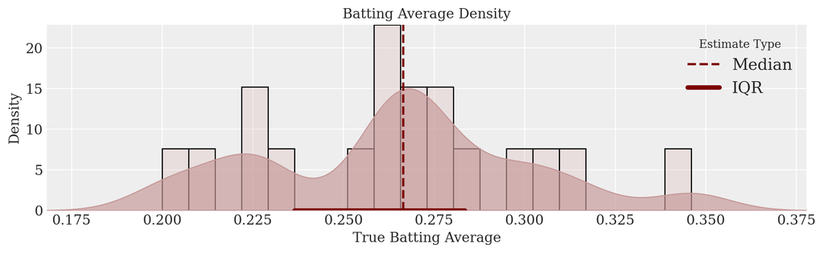

```python
plt.figure(figsize=(10, 3))


sns.histplot(
    baseball['true_batting_average'],
    bins=20,
    color=c_light,
    kde=False,
    stat='density',
    alpha=0.3
)

sns.kdeplot(
    baseball['true_batting_average'],
    color=c_light_highlight,
    fill=True,
    alpha=0.67,
    bw_adjust=0.5
)

median = np.median(baseball['true_batting_average'])
q1 = np.percentile(baseball['true_batting_average'], 25)
q3 = np.percentile(baseball['true_batting_average'], 75)

plt.axvline(median, color=c_dark_highlight, linestyle='--', lw=2, label='Median')
y_iqr = 0.02
plt.plot([q1, q3], [y_iqr, y_iqr], color=c_dark_highlight, lw=4, label='IQR')

plt.title('Batting Average Density', fontsize=12)
plt.xlabel('True Batting Average')
plt.legend(title='Estimate Type', loc='upper right')

plt.show()
```

where $P_i$ is the true average. We don’t know the true average, so we use the normal approximation of the binomial.

$$p_i \dot{\sim} \mathcal{N}(P_i, \sigma_0^2)$$

where $\sigma_0^2$ is the is the binomial squared standard error, which gives us the variance.

$$\sigma_0^2 = \frac{\bar{p}(1 - \bar{p})}{n}$$

Finally, the James-Stein estimate is given by:

$$\hat{p}_i^{\text{JS}} = \bar{p} + \left(1 - \frac{(N - 3)\sigma_0^2}{\Sigma(p_i - \bar{p})^2}\right)(p_i - \bar{p})$$

The factor here adjusts how much the player’s individual estimate $p_i$ is pulled towards the group mean $\bar{p}$

Now, to see the effect of the shrinkage versus without shrinkage we plot the densities.

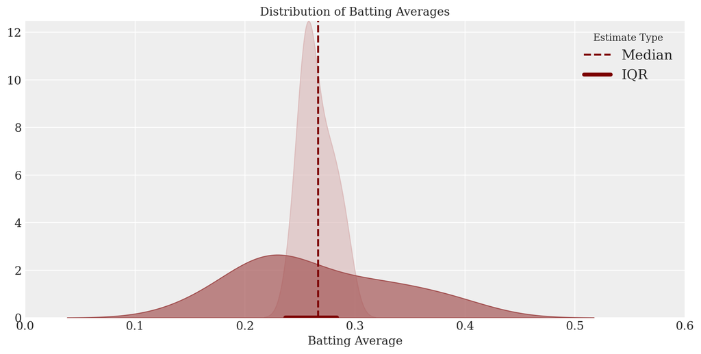

```python
c = 0.212
baseball['y'] = baseball['hits'] / baseball['times_at_bat']
baseball['y_bar'] = baseball['y'].mean()

baseball['z'] = baseball['y_bar'] + c * (baseball['y'] - baseball['y_bar'])
baseball['theta'] = baseball['true_batting_average']

melted_baseball = pd.melt(baseball, value_vars=['y', 'z'])

melted_baseball['label'] = melted_baseball['variable'].map({
    'z': 'The James-Stein estimate',
    'y': 'Early-season batting average'
})

palette = {
    'The James-Stein estimate': c_light,
    'Early-season batting average': c_mid_highlight
}

# Plot
plt.figure(figsize=(10, 5))

sns.kdeplot(data=melted_baseball, x='value', hue='label', palette=palette, fill=True, alpha=0.67)

plt.axvline(median, color=c_dark_highlight, linestyle='--', lw=2, label='Median')
plt.plot([q1, q3], [y_iqr, y_iqr], color=c_dark_highlight, lw=4, label='IQR')

plt.xlabel('Batting Average')
plt.ylabel('')
plt.title('Distribution of Batting Averages')

plt.xlim(0, 0.6)

plt.legend(title='Estimate Type', loc='upper right')
plt.show()
```

We see that the James-Stein estimator is substantially narrower than the early season batting average, which is more diffuse. This jives well with our claim of the James-Stein estimator being a “shrinkage” estimator. Now that we have the distributions we’ll check if we acheived a lower error rate.

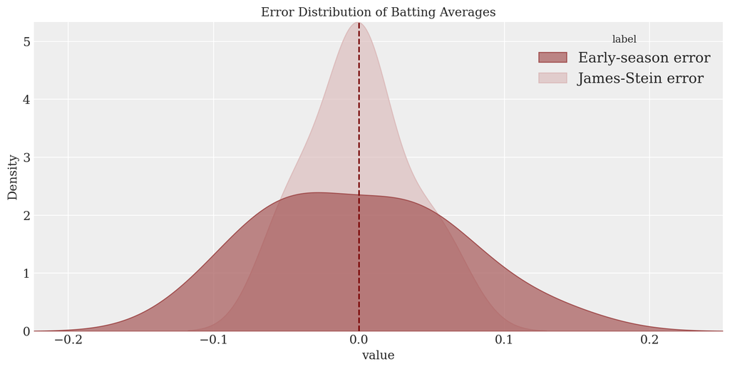

```python
baseball['y_error'] = baseball['theta'] - baseball['y']
baseball['z_error'] = baseball['theta'] - baseball['z']

melted_errors = pd.melt(baseball, value_vars=['y_error', 'z_error'])
melted_errors['label'] = melted_errors['variable'].map({
    'y_error': 'Early-season error',
    'z_error': 'James-Stein error'
})

palette_errors = {
    'Early-season error': c_mid_highlight,
    'James-Stein error': c_light
}
# Plot
plt.figure(figsize=(10, 5))

plot = sns.kdeplot(data=melted_errors, x='value', hue='label', palette=palette_errors, fill=True, alpha=0.67)

plt.axvline(x=0, linestyle='--', color=c_dark_highlight)

plt.title('Error Distribution of Batting Averages')

plt.show()
```

# 4 Is it Even Paradoxical?

At first blush, Stein’s Paradox doesn’t seem all that paradoxical. Okay, sure. Shrinking your estimates towards the sample mean seems to be a better estimate of the end-of-season average rather than the maximum likelihood estimate. The underlying assumption many people have upon encountering this is that there is some common cause for all these baseball players, and our estimate takes into account the effect of this common cause. But James and Stein show us that you can take totally unrelated variables, like batting average and foreign car imports, and shrink the grand average of those variables, resulting in a better estimate! This does rely on the fact that the proportion of imported cars is close to the mean batting average.

Another point of interest I hope to explore elsewhere (lest this turn into a paper) is that the James-Stein estimator is not shift invariant.

Let
$$\mathbf{X} = (X_1, X_2, \dots, X_n)$$
represent a sample of data points, and let $\hat{\theta}(\mathbf{X})$ be an estimator of some parameter $\theta$. The estimator $\hat{\theta}(\mathbf{X})$ is said to be $\textit{shift invariant}$ if, for any constant $c$, the following condition holds:

$$\hat{\theta}(\mathbf{X} + c) = \hat{\theta}(\mathbf{X}) + c$$

where $\mathbf{X} + c = (X_1 + c, X_2 + c, \dots, X_n + c)$.

Shift invariance is one aspect of what is called the Invariance Principle, which intuitively means that inference shouldn’t depend on the idiosyncrasies of our unit of measure or other group-invariant transformations. An interesting fact to note is that invariance might not be such an important property for Bayesians, given that it doesn’t take into account how our prior might behave. I hope to explore these connections in a future post.

# 5 Must Frequentists Care About Admissibaility?

I.J. Good estimated through a combinatorial argument that there are at least $46,656$ types of Bayesianism. According to my humble estimate, there are at least two types of Frequentists. One type, developed by Abraham Wald, is the decision-theoretic strain. The other is the Mayo-Spanos interpretation. I can think of two ways to interpret the former strain: a strict interpretation with limited scope and a loose interpretation with a purported claim to wider scope.

The first interpretation takes the tools decision theory provides (i.e., admissibility, optimality, domination, risk, etc.) and applies a strict interpretation to them. This means that if we confront a decision about our model, then the purpose it’s supposed to serve and the outcomes we care about are immediately well-defined by the loss function that we are considering minimizing. Most likely, we don’t know the most optimal function, but we have some idea of what a good function is for this problem.

For example, if you’re working in manufacturing and wish to measure the error in the machining of some parts for quality control purposes, then you may consider the MSE a fairly good loss function. In industrial decision-making, there is enough outside information about the procedure and the expected quality that you can operationalize the parameter of interest through your loss function. This applies to a wide range of business and industrial decision-making problems.

The difficulty with this strain of frequentism is that we don’t have an uncontroversial loss function in most scientific problems. Instead of speaking of loss functions, we can instead speak of values, and scientists are notoriously at odds regarding what they value in “good” science. They might speak of explanatory power, simplicity, scope, and/or unification. But these are all expressed in extraordinarily different ways. Not only that, but most of these values aren’t easily converted into a function.

So far, we can identify a split between two decision-theoretic-based frequentisms. One thinks Wald’s notions are only properly applied in strict cases. The other considers subsuming the entirety of science under them.

Deborah Mayo and Aris Spanos have argued for a reinterpretation of NP-style frequentism. What’s relevant for our discussion is that Mayo and Spanos warn against taking decision-making as the fundamental guiding aspect of frequentism. They stress that we should care about the fixed state of nature, which we are attempting to estimate. But this contrasts with caring primarily about admissibility. The universal quantifier in our inequality in section $2.1$ requires us to quantify over all values of $\theta$ in our $\Theta$. This is contrary to the fixed state of nature $\theta_{true}$.

The Mayo-Spanos frequentist does not care about decision-making in the traditional sense. They disagree that admissibility is a necessary or sufficient property for a good decision. Instead, they want decisions to be guided by certain frequentist properties. One recommendation is to consider only $consistent$ estimators. A consistent estimator is one for which, when the estimate is considered as a random variable indexed by the number $n$ of items in the dataset, the estimates converge in probability to the value that the estimator is designed to estimate as $n$ increases. Formally, let $\hat{\theta}_n$ be an estimator of a parameter $\theta$ based on a sample of size $n$. The estimator $\hat{\theta}_n$ is weakly consistent if:

$$\lim_{n \to \infty} \Pr\left(|\hat{\theta}_n - \theta| > \varepsilon\right) = 0$$

It is strongly consistent if:

$$\Pr\left(\lim_{n \to \infty} \hat{\theta}_n = \theta\right) = 1$$

Spanos endorses strong consistency as a necessary condition for estimators. However, we would like a definition of consistency that guides decisions when $\theta$ is unknown. But this would require quantifying over all values of $\theta$! It seems a bit strange that the recommendation from the Mayo-Spanos view might involve giving up on evaluating good estimators based on better performance over all possible values of $\theta$.

Now that we have elaborated on some species of frequentism, here are the facets we’ve considered so far:

1. It makes sense to quantify over all values of $\theta$ when considering optimal estimators: (1) always, (2) sometimes, or (3) never.
2. Estimators must be (1) admissible, (2) admissible and consistent, or (3) consistent.
3. Loss functions are (1) always, (2) sometimes, or (3) never sufficiently fine-grained enough to capture what we value.

I would guess that you couldn’t believe in $1.2$ and $2.1$. What seems reasonable to me is to believe in $1.2$, $2.2$, and $3.2$. I don’t have a horse in this race, but I would be hesitant to endorse any operationalizing of frequentism as the strong decision-theoretic view does. We’ll see that in the next section, this worry about operationalism crops up for Bayesians too.

# 6 Must Bayesian Care About Admissability?

## 6.1 Pragmatic Bayesianism

I’m not going to consider the varieties of Bayesianism, which total to the number of people who consider themselves Bayesian. There is a nice discussion of the philosophically relevant strains of Bayesianism and Stein’s paradox in [Vassend, Sober, and Fitelson](https://philsci-archive.pitt.edu/13303/). The view I’m going to take for granted is the pragmatic one that most Bayesian practitioners adopt today. I view this position as putting aside the philosophical inheritance from Savage and other subjectivists or behaviorists, recognizing that priors or credences are inadequately defined or reduced in the myriad of ways they’ve been thought to ([Eriksson and Hajek](https://www.joelvelasco.net/teaching/3865/eriksson%20hajek%20what%20are%20degrees%20of%20belief.pdf)), and being realistic about the fact that Bayesian modeling is going to serve different functions depending on the problem at hand. Models combine both a prior and likelihood, “each of which represents some compromise among scientific knowledge, mathematical convenience, and computational tractability” ([Gleman and Shalzi](http://www.stat.columbia.edu/~gelman/research/published/philosophy.pdf)) and the prior is not necessarily derivable from degrees of belief, the set of default priors, or any other privileged class of priors.

I don’t think it should be controversial to say that most instances of Bayesian inference, decision-making, or predictive modeling aren’t going to agree on what the prior or likelihood mean. It’s likely going to be a process of thinking about the context of the problem (e.g., do I have to optimize for some single decision in a pipeline? Do I have to decide if a treatment is effective or not? Do I wish to understand the underlying generative procedure?, etc.) and the data.

This is all I think is necessary to say to dissuade simple interpretations that our Bayesian forefathers handed down. I don’t think you need to have a positive story that unifies all these themes about modern Bayesianism to have a good methodology as long as you can recognize that thinking about the prior and likelihood together unifies Bayesian modeling.

## 6.2 Bayes Rule and Admissibility

Returning to the original question: must Bayesians care about admissibility? Well, it depends on the problem. Admissibility isn’t the be-all-end-all and isn’t all that important for most problems where we don’t care about the loss function. We might care about some other property if we believe, for example, that the sample median is the optimal estimator, even if we’ve specified a MSE loss function for convenience. I think Bayesians actually have more flexibility in justifying the rejection or acceptance of admissible estimators and the loss functions we find upstream than frequentists. It’s well known that reasonable Bayes rules are typically admissible concerning a specified prior. Bayes rules and admissible estimators likely coincide in many problems. The thought I want to focus on is whether or not Bayesians should care about this fact, given that Mayo-Spanos frequentists do not.

If Bayes’ rule has the same nice properties of admissibility and admissibility is what characterizes frequentist inference, then Bayesianism seems to be superior to frequentism, given that the Bayesian has the added advantage of the prior for flexibility. But Mayo and Spanos deny that admissibility is what characterizes frequentist inference. The weird thing I find with Spanos’ emphasis on $\theta_{true}$ is that most frequentist methods are built on the assumption of asymptotics. Those assumptions rely on the model being perfect, which means the data-generating process your data is coming from has to be in $\Theta$ and, with enough data, there is a narrowing of your set of estimates to your point estimate $\theta_{true}$. The issue with this is that we’ve given some very idealized assumptions. We’ve assumed $\theta_{true}$ is in $\Theta$, and the repeated measurements, which give us our data, have no heterogeneity, correlations, and variations in the underlying process. This isn’t a problem that only plagues frequentists, but it seems to infect Mayo-Spanos style frequentism severely. Any misspecification of the model results in total ruin for those who are after $\theta_{true}$.

# 7 Priors, Shrinkage, and Pooling

The property that the James-Stein estimator puts on display in the baseball example is the ability to shrink each individual mean to the grand mean using a certain factor. The nice thing about this is that in Bayesian modeling, the shrinkage comes from the prior distribution. This becomes especially obvious when we use hierarchical models, which allow us to flexibly shrink our individual parameter estimates by assuming that they all come from some shared distribution yet have their own individual estimate. We strike a compromise between the grand mean and the individual group or individual means.

It’s helpful to have in mind an example when thinking of pooling. For the baseball example, we have a repeated binary trial for $N$ baseball players. Each of these players has some ratio of hits to times-at-bat. Using complete pooling for this results in each player having the same probability of success. This means they all come from the same distribution if we were thinking of the $N$ players as draws from a population with no variance. For our example, complete pooling would consist of having a single parameter for the chance of success for all the batters. No pooling would assume that these players are being drawn from a population with infinite variance. Each of these players has a probability of success that is completely independent of the others. Now, partial pooling strikes a compromise between the extremes. It allows us to encode uncertainty about the population of interest we’re sampling from. We can represent that population through some distribution with finite variance. The idea here is to have a hierarchical structure for each of the players’ parameters, which are describing their hitting ability.

# 8 A Hierarchical Baseball Model

I follow the treatment by [Bob Carpenter](https://mc-stan.org/users/documentation/case-studies/pool-binary-trials.html) for the Stan partial pooling and no pooling model.

## 8.1 Binomial Logit with no Pooling

```python
from cmdstanpy import CmdStanModel, cmdstan_path, set_cmdstan_path

print(baseball.iloc[:, :4])
```

```
         player  hits  times_at_bat  true_batting_average
0      Clemente    18            45                 0.346
1    F Robinson    17            45                 0.298
2      F Howard    16            45                 0.276
3     Johnstone    15            45                 0.222
4         Berry    14            45                 0.273
5       Spencer    14            45                 0.270
6     Kessinger    13            45                 0.263
7    L Alvarado    12            45                 0.210
8         Santo    11            45                 0.269
9       Swoboda    11            45                 0.230
10        Unser    10            45                 0.264
11     Williams    10            45                 0.256
12        Scott    10            45                 0.303
13   Petrocelli    10            45                 0.264
14  E Rodriguez    10            45                 0.226
15   Campaneris     9            45                 0.286
16       Munson     8            45                 0.316
17        Alvis     7            45                 0.200
```

$$\theta_n = \frac{1}{1 + e^{-\alpha_n}} = \text{logit}^{-1}(\alpha_n)$$

$$y_n \sim \text{BinomialLogit}(T_i, \theta_n)$$

Now we can get our data ready for our compiled model and sample using CmdStan.

```
mode1_logit_no_pooling.stan
```

```stan
data {
  int<lower=0> N;              // Number of players
  array[N] int<lower=0> Tr;     // Trials for each player
  array[N] int<lower=0> y;      // Successes for each player
}

parameters {
  vector[N] alpha;              // Logit-transformed chance of success for each player
}

model {
  alpha ~ normal(0, 10);       // Prior for alpha (logit scale)

  for (n in 1:N) {
    target += binomial_logit_lpmf(y[n] | Tr[n], alpha[n]);
  }
}

generated quantities {
   array[N] int y_pred;          // Predicted number of successes
   array[N] real p_hat_pred;              // Mean predicted probability of success

   for (n in 1:N) {
     y_pred[n] = binomial_rng(Tr[n], inv_logit(alpha[n]));
     p_hat_pred[n] = inv_logit(alpha[n]);
   }

}
```

We can define our data dictionary for our model and load our model using CmdStan.

```python
stan_data = {
  'N': len(baseball['player']),
  'Tr': baseball['times_at_bat'],
  'y': baseball['hits'],
}

model_path_1 = os.path.join(current_working_directory, 'models', 'model1_logit_no_pooling.stan')
stan_model_1 = CmdStanModel(stan_file=model_path_1)
```

We fit the model and check for diagnostics now.

```python
fit = stan_model_1.sample(data=stan_data, seed=RANDOM_SEED, chains=4, iter_sampling=2000, iter_warmup=1000, show_progress=False )
```

```
13:50:01 - cmdstanpy - INFO - CmdStan start processing
13:50:01 - cmdstanpy - INFO - Chain [1] start processing
13:50:01 - cmdstanpy - INFO - Chain [2] start processing
13:50:01 - cmdstanpy - INFO - Chain [3] start processing
13:50:01 - cmdstanpy - INFO - Chain [4] start processing
13:50:02 - cmdstanpy - INFO - Chain [3] done processing
13:50:02 - cmdstanpy - INFO - Chain [2] done processing
13:50:02 - cmdstanpy - INFO - Chain [4] done processing
13:50:02 - cmdstanpy - INFO - Chain [1] done processing
```

```python
print(fit.diagnose())
```

```
Processing csv files: C:\Users\ISSAM_~1\AppData\Local\Temp\tmpopw2zneq\model1_logit_no_poolingd8cdx05q\model1_logit_no_pooling-20241007135001_1.csv, C:\Users\ISSAM_~1\AppData\Local\Temp\tmpopw2zneq\model1_logit_no_poolingd8cdx05q\model1_logit_no_pooling-20241007135001_2.csv, C:\Users\ISSAM_~1\AppDat…

Checking sampler transitions treedepth.
Treedepth satisfactory for all transitions.

Checking sampler transitions for divergences.
No divergent transitions found.

Checking E-BFMI - sampler transitions HMC potential energy.
E-BFMI satisfactory.

Effective sample size satisfactory.

Split R-hat values satisfactory all parameters.

Processing complete, no problems detected.
```

Everything looks fine. We can plot our posterior predictive check to see how our no pooling model replicated the true batting averages. Here is a summary of our model fit and generated quantities. Everything looks pretty good.

```python
output = fit.summary(percentiles=(5, 50, 95), sig_figs=6)
print(output)
```

```
                     Mean      MCSE    StdDev         5%        50%  \
lp__           -45.158500  0.064482  3.038530 -50.592100 -44.810600
alpha[1]        -0.416262  0.002129  0.306855  -0.928830  -0.414002
alpha[2]        -0.510640  0.002217  0.312236  -1.030860  -0.504429
alpha[3]        -0.607732  0.002212  0.309840  -1.121190  -0.601879
alpha[4]        -0.711733  0.002383  0.322517  -1.257140  -0.703914
alpha[5]        -0.815590  0.002497  0.330557  -1.370300  -0.810103
alpha[6]        -0.817324  0.002403  0.323989  -1.357860  -0.810950
alpha[7]        -0.924998  0.002584  0.341652  -1.503300  -0.919467
alpha[8]        -1.037390  0.002460  0.332247  -1.593070  -1.032730
alpha[9]        -1.156750  0.002548  0.357371  -1.771640  -1.143840
alpha[10]       -1.160130  0.002613  0.356644  -1.769180  -1.144900
alpha[11]       -1.287640  0.002597  0.375680  -1.925090  -1.275410
alpha[12]       -1.289090  0.002732  0.361543  -1.907470  -1.278770
alpha[13]       -1.284620  0.002728  0.367312  -1.918880  -1.271320
alpha[14]       -1.286700  0.002836  0.362499  -1.901300  -1.274040
alpha[15]       -1.285880  0.002720  0.364642  -1.906100  -1.273940
alpha[16]       -1.421960  0.002703  0.375895  -2.062690  -1.409960
alpha[17]       -1.578110  0.002989  0.402005  -2.266880  -1.562700
alpha[18]       -1.749130  0.003352  0.420999  -2.461340  -1.726590
y_pred[1]       17.952600  0.042752  4.615440  10.000000  18.000000
y_pred[2]       16.994200  0.043285  4.596700  10.000000  17.000000
y_pred[3]       15.945200  0.041726  4.476690   9.000000  16.000000
y_pred[4]       15.033600  0.040538  4.408220   8.000000  15.000000
y_pred[5]       14.010200  0.041986  4.324840   7.000000  14.000000
y_pred[6]       13.906600  0.040439  4.288930   7.000000  14.000000
y_pred[7]       13.048100  0.040699  4.277860   6.000000  13.000000
y_pred[8]       11.976400  0.040026  4.099840   6.000000  12.000000
y_pred[9]       10.999800  0.038663  4.038720   5.000000  11.000000
y_pred[10]      10.998900  0.037719  4.052640   5.000000  11.000000
y_pred[11]      10.103200  0.035365  3.985330   4.000000  10.000000
y_pred[12]      10.016000  0.038151  3.847060   4.000000  10.000000
y_pred[13]      10.041700  0.037026  3.897100   4.000000  10.000000
y_pred[14]       9.987250  0.036800  3.918800   4.000000  10.000000
y_pred[15]      10.021400  0.036613  3.960130   4.000000  10.000000
y_pred[16]       9.044750  0.036844  3.770150   3.000000   9.000000
y_pred[17]       8.093250  0.032784  3.600060   3.000000   8.000000
y_pred[18]       6.970120  0.032508  3.368260   2.000000   7.000000
p_hat_pred[1]    0.399663  0.000496  0.071897   0.283162   0.397953
p_hat_pred[2]    0.377802  0.000507  0.071677   0.262917   0.376500
```

[output cut: 58 more lines]

```
p_hat_pred[4]    0.451946  19943.80  26276.40  0.999709
p_hat_pred[5]    0.430928  17870.70  23545.10  0.999889
p_hat_pred[6]    0.426002  18822.90  24799.60  0.999608
p_hat_pred[7]    0.406698  17935.70  23630.70  0.999745
p_hat_pred[8]    0.375840  18143.30  23904.20  0.999545
p_hat_pred[9]    0.356408  20588.60  27126.00  0.999568
p_hat_pred[10]   0.355859  19013.10  25050.20  0.999637
p_hat_pred[11]   0.336152  21971.30  28947.70  0.999567
p_hat_pred[12]   0.327687  18694.40  24630.30  0.999722
p_hat_pred[13]   0.331748  20071.50  26444.70  0.999656
p_hat_pred[14]   0.330340  16912.30  22282.30  0.999655
p_hat_pred[15]   0.331513  20384.20  26856.70  0.999669
p_hat_pred[16]   0.303472  19771.50  26049.40  0.999790
p_hat_pred[17]   0.278550  19791.00  26075.10  0.999653
p_hat_pred[18]   0.251551  17855.30  23524.80  0.999803
```

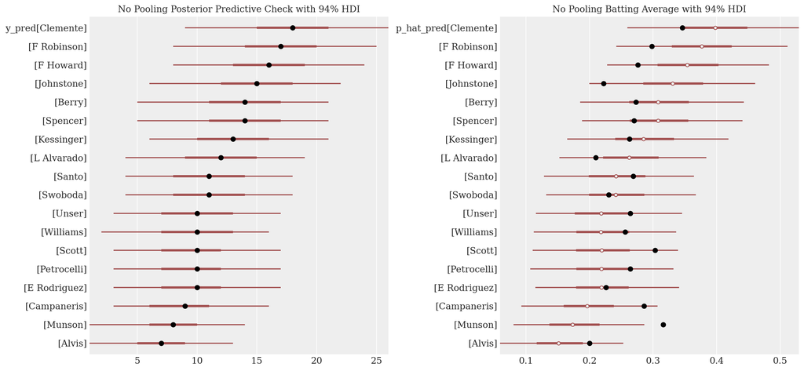

```python
fig, axes = plt.subplots(1, 2, figsize=(15, 7))  # Adjust size as needed

# First subplot: Posterior Predictive Check
idata_1 = az.from_cmdstanpy(
    posterior=fit,
    observed_data={'y': baseball['hits']},
    dims={'y_pred': ['player'], 'alpha': ['player']},
    coords={'player': baseball['player']}
)

az.plot_forest(
    idata_1,
    kind='forestplot',
    var_names=["y_pred"],
    filter_vars="regex",
    combined=True,
    colors=[c_mid_highlight],
    ax=axes[0],
)

y_ticks = axes[0].get_yticks()
axes[0].scatter(baseball['hits'], list(reversed(y_ticks)), color='black', zorder=3, label='True Values')
axes[0].set_ylim(min(y_ticks) - 0.5, max(y_ticks) + 0.5)
axes[0].set_title('No Pooling Posterior Predictive Check with 94% HDI')

# Second subplot: Batting Average
idata_2 = az.from_cmdstanpy(
    posterior=fit,
    observed_data={'y': baseball['hits']},
    dims={'y_pred': ['player'], 'p_hat_pred': ['player']},
    coords={'player': baseball['player']}
)

az.plot_forest(
    idata_2,
    kind='forestplot',
    var_names=["p_hat_pred"],
    filter_vars="regex",
    combined=True,
    colors=[c_mid_highlight],
    ax=axes[1],
)

y_ticks_2 = axes[1].get_yticks()
axes[1].scatter(baseball['true_batting_average'], list(reversed(y_ticks_2)), color='black', zorder=3, label='True Batting Average')
axes[1].set_ylim(min(y_ticks_2) - 0.5, max(y_ticks_2) + 0.5)
axes[1].set_title('No Pooling Batting Average with 94% HDI')

plt.tight_layout()
plt.show()
```

## 8.2 Hierachical Binomial Logit

We observed that we had a fairly generic fit of our data with our model, which is to be expected. Now we can implement some partial pooling to account for our knowledge about the shared baseball player distribution from which our players originate. We will use the same model as before but add a hyperprior on our batting ability. We can provide some weakly informative hyperprior on where our values tend to cluster. Based on our graph, we assume, as a first approximation, that they are distributed according to a half-normal. All the values are between $0$ and $1$, so we can satisfactorily specify our deviation for $\sigma$ as $1$.

$$\alpha_n \vert \mu, \sigma \sim \mathcal{N}(\mu, \sigma)$$

$$\sigma \sim \mathcal{N}(0, 1)$$

$$\theta_n = \frac{1}{1 + e^{-\alpha_n}} = \text{logit}^{-1}(\alpha_n)$$

$$y_n \sim \text{BinomialLogit}(T_i, \theta_n)$$

```
model2_logit_partial_pooling.stan
```

```stan
data {
  int<lower=0> N;              // Number of players
  array[N] int<lower=0> Tr;     // Trials for each player
  array[N] int<lower=0> y;      // Successes for each player
}

parameters {
  vector[N] alpha;              // Logit-transformed chance of success for each player
  real mu;
  real<lower=0> sigma;
}

model {
  sigma ~ normal(0, 1);   // Hyperprior
  mu ~ normal(0.3, sigma);    // Hyperprior
  alpha ~ normal(mu, sigma);

  for (n in 1:N) {
    target += binomial_logit_lpmf(y[n] | Tr[n], mu + alpha[n] * sigma);
  }
}

generated quantities {
   array[N] int y_pred;          // Predicted number of successes
   array[N] real p_hat_pred;              // Mean predicted probability of success


   for (n in 1:N) {
     y_pred[n] = binomial_rng(Tr[n], inv_logit(mu + alpha[n] * sigma));
     p_hat_pred[n] = inv_logit(mu + alpha[n] * sigma);
   }

}
```

```python
model_path_2 = os.path.join(current_working_directory, 'models', 'model2_logit_partial_pooling.stan')
stan_model_2 = CmdStanModel(stan_file=model_path_2)
```

We fit the model and check for diagnostics now.

```python
fit2 = stan_model_2.sample(data=stan_data, seed=RANDOM_SEED, chains=4, iter_sampling=2000, iter_warmup=1000, show_progress=False)
```

```
13:50:09 - cmdstanpy - INFO - CmdStan start processing
13:50:09 - cmdstanpy - INFO - Chain [1] start processing
13:50:09 - cmdstanpy - INFO - Chain [2] start processing
13:50:09 - cmdstanpy - INFO - Chain [3] start processing
13:50:09 - cmdstanpy - INFO - Chain [4] start processing
13:50:09 - cmdstanpy - INFO - Chain [2] done processing
13:50:10 - cmdstanpy - INFO - Chain [1] done processing
13:50:10 - cmdstanpy - INFO - Chain [3] done processing
13:50:10 - cmdstanpy - INFO - Chain [4] done processing
13:50:10 - cmdstanpy - WARNING - Non-fatal error during sampling:
Exception: binomial_logit_lpmf: Probability parameter is -inf, but must be finite! (in 'model2_logit_partial_pooling.stan', line 19, column 4 to column 71)
Exception: binomial_logit_lpmf: Probability parameter is -inf, but must be finite! (in 'model2_logit_partial_pooling.stan', line 19, column 4 to column 71)
Exception: binomial_logit_lpmf: Probability parameter is inf, but must be finite! (in 'model2_logit_partial_pooling.stan', line 19, column 4 to column 71)
Exception: binomial_logit_lpmf: Probability parameter is -inf, but must be finite! (in 'model2_logit_partial_pooling.stan', line 19, column 4 to column 71)
Consider re-running with show_console=True if the above output is unclear!
```

Even though we achieve convergence with good diagnostics, we still encounter the following error while fitting our model: “Exception: binomial_logit_lpmf: Probability parameter is -inf.” This is largely because we are using a centered parameterization. A quick fix is the model below that employs a non-centered parameterization.

```python
print(fit2.diagnose())
```

```
Processing csv files: C:\Users\ISSAM_~1\AppData\Local\Temp\tmpopw2zneq\model2_logit_partial_poolingq_orbb9w\model2_logit_partial_pooling-20241007135009_1.csv, C:\Users\ISSAM_~1\AppData\Local\Temp\tmpopw2zneq\model2_logit_partial_poolingq_orbb9w\model2_logit_partial_pooling-20241007135009_2.csv, C:\U…

Checking sampler transitions treedepth.
Treedepth satisfactory for all transitions.

Checking sampler transitions for divergences.
No divergent transitions found.

Checking E-BFMI - sampler transitions HMC potential energy.
E-BFMI satisfactory.

Effective sample size satisfactory.

Split R-hat values satisfactory all parameters.

Processing complete, no problems detected.
```

```
non-centered_model2.stan
```

```stan
data {
  int<lower=0> N;              // Number of players
  array[N] int<lower=0> Tr;     // Trials for each player
  array[N] int<lower=0> y;      // Successes for each player
}

parameters {
  vector[N] alpha_raw;          // Raw parameters to be scaled
  real mu;
  real<lower=0> sigma;
}

transformed parameters {
  vector[N] alpha;
  alpha = mu + sigma * alpha_raw; // Scaling alpha_raw by sigma
}

model {
  // Priors
  sigma ~ normal(0, 1);
  mu ~ normal(0.3, 1);
  alpha_raw ~ normal(0, 1);

  // Likelihood
  for (n in 1:N) {
    target += binomial_logit_lpmf(y[n] | Tr[n], alpha[n]);
  }
}

generated quantities {
  array[N] int y_pred;          // Predicted number of successes
  array[N] real p_hat_pred;     // Mean predicted probability of success

  for (n in 1:N) {
    p_hat_pred[n] = inv_logit(alpha[n]);
    y_pred[n] = binomial_rng(Tr[n], p_hat_pred[n]);
  }
}
```

We quickly rerun it to check if the errors are resolved.

```python
model_path_2 = os.path.join(current_working_directory, 'models', 'non-centered_model2.stan')
stan_model_2 = CmdStanModel(stan_file=model_path_2)
```

We fit the model again and see that the errors are gone. Although the centered parameterization doesn’t significantly affect our results in this case, it typically has a negative impact on convergence in our numerical calculations of the log density.

```python
fit2 = stan_model_2.sample(data=stan_data, seed=RANDOM_SEED, chains=4, iter_sampling=2000, iter_warmup=1000, show_progress=False)
```

```
13:50:14 - cmdstanpy - INFO - CmdStan start processing
13:50:14 - cmdstanpy - INFO - Chain [1] start processing
13:50:14 - cmdstanpy - INFO - Chain [2] start processing
13:50:14 - cmdstanpy - INFO - Chain [3] start processing
13:50:14 - cmdstanpy - INFO - Chain [4] start processing
13:50:15 - cmdstanpy - INFO - Chain [2] done processing
13:50:15 - cmdstanpy - INFO - Chain [3] done processing
13:50:15 - cmdstanpy - INFO - Chain [4] done processing
13:50:16 - cmdstanpy - INFO - Chain [1] done processing
```

As we can see below, we achieve a considerable number of our point predictions and intervals closer to the true values.

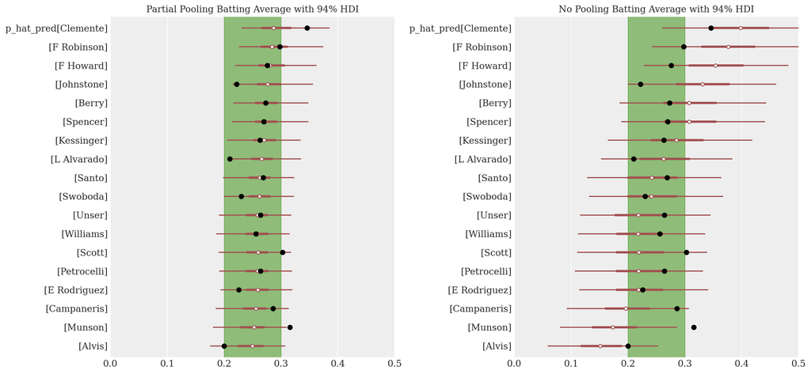

```python
fig, axes = plt.subplots(1, 2, figsize=(15, 7))

idata_3 = az.from_cmdstanpy(
    posterior=fit2,
    observed_data={'y': baseball['hits']},
    dims={'y_pred': ['player'], 'p_hat_pred': ['player']},
    coords={'player': baseball['player']}

)

az.plot_forest(
    idata_3,
    kind='forestplot',
    var_names=["p_hat_pred"],
    filter_vars="regex",
    combined=True,
    colors=[c_mid_highlight],
    ax=axes[0],
    rope = [.2, .3],
)

y_ticks_3 = axes[0].get_yticks()
axes[0].scatter(baseball['true_batting_average'], list(reversed(y_ticks_3)), color='black', zorder=3, label='True Batting Average')
axes[0].set_ylim(min(y_ticks_3) - 0.5, max(y_ticks_3) + 0.5)
axes[0].set_title('Partial Pooling Batting Average with 94% HDI')

idata_2 = az.from_cmdstanpy(
    posterior=fit,
    observed_data={'y': baseball['hits']},
    dims={'y_pred': ['player'], 'p_hat_pred': ['player']},
    coords={'player': baseball['player']}
)

az.plot_forest(
    idata_2,
    kind='forestplot',
    var_names=["p_hat_pred"],
    filter_vars="regex",
    combined=True,
    colors=[c_mid_highlight],
    ax=axes[1],
    rope = [.2, .3]
)

y_ticks_4 = axes[1].get_yticks()
axes[1].scatter(baseball['true_batting_average'], list(reversed(y_ticks_4)), color='black', zorder=3, label='True Batting Average')
axes[1].set_ylim(min(y_ticks_4) - 0.5, max(y_ticks_4) + 0.5)
axes[1].set_title('No Pooling Batting Average with 94% HDI')

axes[1].set_xlim(0, 0.5)
axes[0].set_xlim(0, 0.5)

plt.tight_layout()
plt.show()
```

The effect we observe here is very similar to what occurs for the James-Stein estimator. However, it is markedly different from a vanilla Bayes estimator that provides only a constant shrinkage factor through some non-empirical prior. Note that the James-Stein estimator can be derived from an empirical Bayes approach [(Effron and Morris, 1973)](https://www.jstor.org/stable/2284155).

# 9 Conclusion

There is a nice interplay between the geometric properties of higher-dimensional spaces and the way probability densities behave.

```python
from scipy.spatial import distance_matrix

def generate_points_on_hypersphere(n_points, dimensions):
    points = np.random.randn(n_points, dimensions)
    points /= np.linalg.norm(points, axis=1)[:, np.newaxis]
    return points

n_points = 100
dims = [3, 10, 30]
distances = []
```

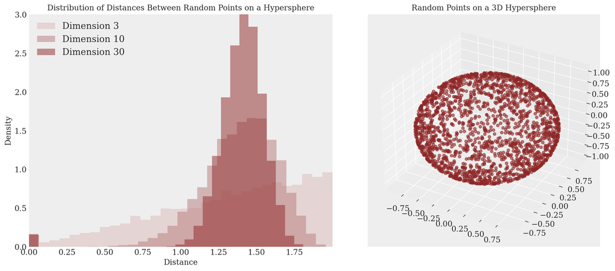

```python
fig = plt.figure(figsize=(14, 6))

ax1 = fig.add_subplot(121)
colors = [c_light, c_mid, c_dark]
for i, d in enumerate(dims):
    points = generate_points_on_hypersphere(n_points, d)
    dists = distance_matrix(points, points)
    distances.append(dists.flatten())
    ax1.hist(dists.flatten(), bins=30, alpha=0.5, label=f'Dimension {d}', density=True, color=colors[i])

ax1.set_xlabel('Distance')
ax1.set_ylabel('Density')
ax1.set_title('Distribution of Distances Between Random Points on a Hypersphere')
ax1.legend()
ax1.grid()

ax2 = fig.add_subplot(122, projection='3d')
n_points_3d = 2000
points_3d = generate_points_on_hypersphere(n_points_3d, dimensions=3)
ax2.scatter(points_3d[:, 0], points_3d[:, 1], points_3d[:, 2], alpha=0.6, color=c_dark)
ax2.set_title('Random Points on a 3D Hypersphere')

plt.tight_layout()
plt.show()
```

As the number of dimensions increases in Euclidean space, the geometry behaves quite differently compared to lower-dimensional spaces. In high-dimensional spaces, most of the volume of a hypersphere is concentrated near its surface rather than in its center. This means that points sampled uniformly from a high-dimensional space are likely to be found near the edges rather than close to the origin. An additional concern is that as dimensions increase, the distances between random points become more uniform, making it difficult to distinguish between them. The distances between points tend to cluster around a mean distance, complicating the identification of whether two points are close or far apart.

The concept of volume in high-dimensional spaces is also counterintuitive. While the volume of a hypersphere grows with the dimension, the volume of the enclosing hypercube grows as well. As dimensions increase, the ratio of the volume of the hypersphere to that of the hypercube decreases significantly, indicating that the actual “usable” volume—where most points are likely to lie—becomes smaller relative to the total volume available. When shrinkage is applied to an estimator, it effectively constrains the estimator to a smaller region of space. In high dimensions, this can lead to a significant loss of volume, especially if the shrinkage target is poorly chosen. You’re likely to get a good estimate of where density is most concentrated, but you may miss any density that shows up in the tails. This is nicely illustrated in the distance metric distributions above, where some of the random points cluster near each other far away from the others, usually in the tails.

Overall, the behavior of estimators in high-dimensional spaces is influenced by the geometry described above. We’ve seen that the Stein Effect occurs when a shrinkage estimator provides better estimates than an unbiased estimator because the shrinkage brings the estimates closer to the truth—typically zero—while accounting for the concentration of measure. The curvature of the sphere helps justify why shrinking towards a central point, such as the origin, can be beneficial, as it reduces variance more effectively than simply using the sample mean. However, the Reverse Stein Effect highlights the risks of using shrinkage without a reliable target. If the shrinkage target is selected based on data $X$ without understanding its true relationship to the parameter $\delta$, there is a danger of shrinking to a point that is far from the actual parameter location. The curvature of the hypersphere exacerbates this issue by making it challenging to assess how far the shrinkage target is from the true parameter, particularly when the data points are concentrated at the boundaries. [Perlman and Chaudhuri](https://arxiv.org/abs/1203.5626) have a fascinating little paper that elaborates on this, with the added benefit of a mashup of Star Trek and statistics in the explanation.

# 10 Acknowledgements

If you’ve happened across [Michael Betancourt’s](https://betanalpha.github.io/) beautiful writeups you’d recognize the overall typesetting and styling for the CSS and graphics. I really liked that style, so I’ve adapted it to my purposes.

Note: I’ll likely write up the references later if I have the time.